# Revenue Forecasting using Machine Learning

### Simon Guichandut - May 2025

This notebook goes through some exploratory data analysis, feature selection, model building and validation. We will look at models with increasing complexity: moving average, linear regression, and finally boosted regression trees.

```python
# Packages

import numpy as np
import matplotlib.pyplot as plt
import seaborn as sns
import pandas as pd

from sklearn.metrics import mean_squared_error, mean_absolute_percentage_error
from sklearn.linear_model import Ridge
from sklearn.multioutput import MultiOutputRegressor
from sklearn.model_selection import TimeSeriesSplit
from sklearn.preprocessing import StandardScaler

from tqdm.notebook import tqdm

import lightgbm as lgb

import warnings
warnings.simplefilter(action='ignore', category=FutureWarning)  # silences some pandas warnings
```

```python
# plotting config
%matplotlib inline
# save_plots = False # plots for the report
```

```python
# Load the full dataset (takes a few minutes)
df = pd.read_csv("./df_contest_train_main.csv")
df.info()
```

```
<class 'pandas.core.frame.DataFrame'>
RangeIndex: 3838753 entries, 0 to 3838752
Columns: 110 entries, as_of_date to GICS_code_prefix
dtypes: float64(103), int64(3), object(4)
memory usage: 3.1+ GB
```

```python
# Examining the columns

# dictionary table has the column descriptions
dic_table = pd.read_csv("./data_dictionary.csv", sep=';')

for key in df.keys():
    if key not in list(dic_table['Field']):
        print(key, " is not in data_dictionary")
```

```
GICS_code  is not in data_dictionary
id_security_mapped  is not in data_dictionary
GICS_code_prefix  is not in data_dictionary
```

```python
df[['id_security_mapped','GICS_code','GICS_code_prefix']].sample(5)
```

|  | id_security_mapped | GICS_code | GICS_code_prefix |
| --- | --- | --- | --- |
| 2177020 | 1803 | 10101020 | 10 |
| 1589811 | 1227 | 45203010 | 45 |
| 670560 | 1485 | 40203020 | 40 |
| 528096 | 457 | 25301040 | 25 |
| 123455 | 837 | 20201030 | 20 |

`id_security_mapped` is just `id_security`. `GICS_code` and `GICS_code_prefix` are sector codes. Importantly, these are **categorical** variables, not numeric; we can hardcode this in.

```python
df.rename(columns={"id_security_mapped":"id_security"}, inplace=True)
df['id_security'] = df.id_security.astype('category')
df['GICS_code'] = df.GICS_code.astype('category')
df['GICS_code_prefix'] = df.GICS_code_prefix.astype('category')
```

## Understanding `as_of_date` vs. `datadate`

Let's plot the revenues of one company vs. datadate, for different snapshot dates (`as_of_date`)

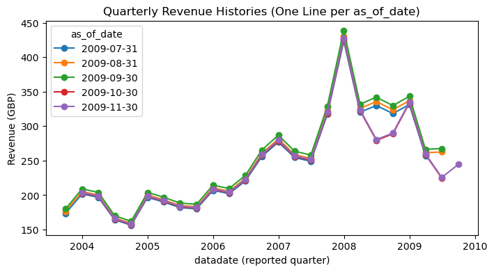

```python
df_company = df[df['id_security'] == 1105].copy() # I found that this id illustrates the point well

# Convert to datetime
df_company['as_of_date'] = pd.to_datetime(df_company['as_of_date'])
df_company['datadate'] = pd.to_datetime(df_company['datadate'])

# select the 5 last as_of_dates
latest_as_of_dates = df_company['as_of_date'].drop_duplicates().sort_values().tail(5)

# Plot the revenues
fig = plt.figure(figsize = (8,4))

for as_of in latest_as_of_dates:
    subset = df_company[df_company['as_of_date'] == as_of].sort_values('datadate')
    plt.plot(subset['datadate'], subset['revtq'], marker='o', label=as_of.date())

plt.legend(title = 'as_of_date', loc='best')
plt.xlabel('datadate (reported quarter)')
plt.ylabel('Revenue (GBP)')

if save_plots:
    plt.title('')
    fig.savefig('plots/revs_date.pdf', bbox_inches='tight')

plt.title('Quarterly Revenue Histories (One Line per as_of_date)')
plt.show()
```

We see that the revenues at a given date change with snapshots (for example, revenues in 2008 dropped after the september 2009 snapshot). This is because new financial statements may *update* past information. It is important that we **keep** these different values, and only make predictions based on what was known **at the time**.

Our strategy will be to build a training set with **one row per as_of_date, per id_security**. We will also include *lagged features*, i.e. column values from previous quarters (same `as_of_date`, different `datadate`). This is our way of including the company's recent history as inputs to the model. We will only consider at most 4 lagged features (4 quarters/1 year). This is a somewhat arbitrary choice. But generally speaking, we do not want to include too many lagged features, otherwise the model complexity will be too large for the amount of data, increasing the risk of overfitting.

Since we do not need the full history for each `as_of_date`, we can immediately reduce the dataset, keeping only the last 4 `datadates` for each `as_of_date` and `id_security`. This will ease the memory load of this code (I am using a very old laptop).

```python
# Sort so that the most recent datadates come first (per group)
df_sorted = df.sort_values(['id_security', 'as_of_date', 'datadate'], ascending=[True, True, False])

# Keep only the 4 most recent datadate entries per (id_security, as_of_date)
df_filtered = (
    df_sorted
    .groupby(['id_security', 'as_of_date'],
             observed = True) # this is just to silence a warning
    .head(4)   # keep top 4 rows per group
    .reset_index(drop=True)
)

df_filtered.info()
```

```
<class 'pandas.core.frame.DataFrame'>
RangeIndex: 658855 entries, 0 to 658854
Columns: 110 entries, as_of_date to GICS_code_prefix
dtypes: category(3), float64(103), object(4)
memory usage: 541.1+ MB
```

We reduced the memory usage by a factor of ~6. Phew!

```python
# alias back to "df" for readability
df = df_filtered.copy()

df['id_security'] = df.id_security.astype('category')
df['GICS_code'] = df.GICS_code.astype('category')
df['GICS_code_prefix'] = df.GICS_code_prefix.astype('category')
```

```python
# Easier to perform this conversion now
df['datadate'] = pd.to_datetime(df['datadate'])
df['as_of_date'] = pd.to_datetime(df['as_of_date'])

# The total number of rows in the dataset
Ntot = len(df)
```

## Baseline model: Moving Average

Let's visualize moving average for one company.

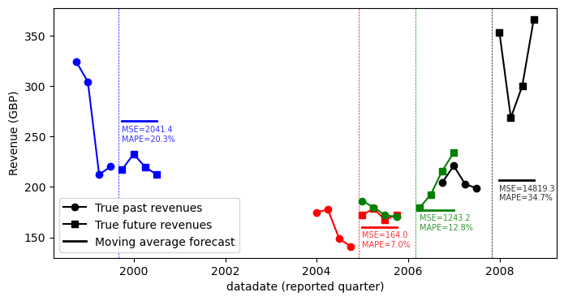

```python
df_company = df[df['id_security'] == 1105].copy()
test_as_of_dates = df_company['as_of_date'].drop_duplicates().sample(4, random_state=42)

plt.figure(figsize=(8,4))
colors = ['k','b','r','g']

for i, as_of in enumerate(test_as_of_dates):

    plt.axvline(as_of, lw=0.5, ls='--', color=colors[i])

    # Past revenues
    past_data = df_company[(df_company['as_of_date'] == as_of) & (df_company['datadate'] <= as_of)]
    past_data = past_data.sort_values('datadate')
    past_dates = past_data['datadate'].values[-4:]
    past_revs = past_data['revtq'].values[-4:]
    plt.plot(past_dates, past_revs, 'o-', color=colors[i], label="True past revenues" if i==0 else None)

    # True future revenues
    fut_data = df_company[df_company['datadate'] > as_of].drop_duplicates('datadate')
    fut_data = fut_data.sort_values('datadate')
    fut_dates = fut_data['datadate'].values[:4]
    fut_revs = fut_data['revtq'].values[:4]
    plt.plot(fut_dates, fut_revs, 's-', color=colors[i], label="True future revenues" if i==0 else None)

    # MA4 forecasted revenues
    forecast = np.ones(4) * np.mean(past_revs)
    plt.plot(fut_dates, forecast, '-', lw=2, color=colors[i], label="Moving average forecast" if i==0 else None)

    # display the errors
    mse = mean_squared_error(fut_revs, forecast)
    mape = mean_absolute_percentage_error(fut_revs, forecast)

    plt.text(fut_dates[0], forecast[0]-20, f"MSE={mse:.1f}\nMAPE={mape*100:.1f}%", color=colors[i], fontsize=7, alpha=0.8)

plt.legend()
plt.xlabel('datadate (reported quarter)')
plt.ylabel('Revenue (GBP)')
plt.show()
```

This model is obviously not very good. It can be good sometimes but only if the revenue evolution is stable. When factors other than recent history are at play, MA doesn't stand a chance (for example, black line). We can beat it by taking advantage of the many features in the data.

## Feature selection for regression models

- From **price**-related features, we only select `prccd_as_of_date_adj_GBP`, the adjusted GBP price at the as_of_date. This is the most stable and comparable price metric across securities.
- From fundamental **buisness**-related features, we include every quarterly feature (ends with the letter 'q'), as long as it contains enough data. We set the threshold to 80% valid data (non-NaN). We also include lagged version of some of those features.
- We do not include any yearly features (ends with 'y'). Most of them are just the cumulative quarterlies, it would be redundant to include them. For the yearly features that do not have a quarterly equivalent (e.g. `xidocy`, `rvy`, tax-related columns), I found by inspection that their values were ambiguous, i.e. it was not clear if they were cumulatives or not. This matters; if they are cumulative, we would need to decumulate them to obtain true quarterly values. Because of this confusion, I decided not to include any of these columns.
- We do not include the employees (`emp`) column. It has too many missing values.
- We will look at categorical variables next.
- Later in this notebook, I will also introduce **macroeconomic** features.

```python
def good_col(col):
    # We consider a column good if the fraction of NA values is less than 20%
    if df[col].isna().sum()/Ntot < 0.2:
        return True
    return False
```

```python
# initialize the features with the price
feature_cols = ['prccd_as_of_date_adj_GBP']

candidate_cols = df.columns
exclude_cols = ['as_of_date','id_security','datadate','is_final_q','is_final_a'] # not used for regression

# Additionally, we don't include any column which includes "date" (as_of_date or data_date)
# These refer to the price of the security in different currencies as well as exchange rates. we don't need those.
for col in candidate_cols:
    if 'date' in col and col not in exclude_cols:
        exclude_cols.append(col)
candidate_cols = [col for col in candidate_cols if col not in exclude_cols]

quarterly_cols = [col for col in candidate_cols if col.endswith('q')]
for col in quarterly_cols:
    if good_col(col):
        feature_cols.append(col)

print("Feature columns")
print('\t' + feature_cols[0])
for i in range(1,len(feature_cols)//4):
    print('\t' + ', '.join(feature_cols[i:i+5]))
```

```
Feature columns
	prccd_as_of_date_adj_GBP
	actq, aoq, apq, atq, ceqq
	aoq, apq, atq, ceqq, cheq
	apq, atq, ceqq, cheq, dlcq
	atq, ceqq, cheq, dlcq, dlttq
	ceqq, cheq, dlcq, dlttq, icaptq
	cheq, dlcq, dlttq, icaptq, intanq
	dlcq, dlttq, icaptq, intanq, invtq
```

### Lagged features

We add lagged version of core buisness features:

- Revenue (`revtq`)
- Income (`ibq`)
- Assets (`atq`)
- Liquidity (`cheq`)
- Expenses (`xoprq`)

```python
def add_lagged_features(df, lag_columns, max_lag=2):
    """
    Adds lagged versions of selected features within each as_of_date snapshot.
    For example, for revtq and max_lag=2, creates revtq_lag1 and revtq_lag2.
    """
    df = df.copy()
    df = df.sort_values(['id_security', 'as_of_date', 'datadate'])

    for col in lag_columns:
        for lag in range(1, max_lag + 1):
            lagged_name = f"{col}_lag{lag}"
            df[lagged_name] = (df.groupby(['id_security','as_of_date'])[col]
                                  .shift(lag))
    return df
```

```python
# Demo of add_lagged_features, to prove that there is no info leakage between ids or as_of_dates
# Uncomment below to see the demo

# # Filter to only the revtq feature, and the first 2 companies
# demo_df = df[['id_security', 'as_of_date', 'datadate', 'revtq']].dropna().sort_values(['id_security', 'as_of_date', 'datadate'])
# demo_df = demo_df[demo_df['id_security'].isin([1,2])]

# # Apply lag
# demo_lagged = add_lagged_features(demo_df, ['revtq'], max_lag=2)

# # Display
# print(demo_lagged.sort_values(['id_security', 'as_of_date', 'datadate']).to_string(max_rows=20))
```

```python
lag_vars = ['revtq', 'ibq', 'atq', 'cheq', 'xoprq']
max_lag = 2
df = add_lagged_features(df, lag_columns=lag_vars, max_lag=max_lag)

lag_feature_cols = [f"{col}_lag{lag}" for col in lag_vars for lag in range(1, max_lag+1)]
```

### Categorical features

```python
print(len(pd.unique(df['id_security'])), ' unique securities')
print(len(pd.unique(df['GICS_code'])), ' unique GICS codes')
print(len(pd.unique(df['GICS_code_prefix'])), ' unique GICS code prefixes')
```

```
1949  unique securities
209  unique GICS codes
11  unique GICS code prefixes
```

- For simple (linear) models, it only makes sense to include `GICS_code_prefix` (the sector code). We can include it in the training set via one-hot encoding.
- In contract, non-linear tree-based models are built to handle categorical features with high cardinality. We will therefore use both `GICS_code_prefix` and `id_security`.

```python
# Add the one-hot encoded variables
one_hot = pd.get_dummies(df['GICS_code_prefix'], prefix='sector', drop_first=True)

categorical_linear_cols = one_hot.columns.tolist()
categorical_non_linear_cols = ['GICS_code_prefix', 'id_security']
```

```python
# Add into the master df
df = pd.concat([df, one_hot], axis=1)
```

### Macroeconomic features

We obtain US macroeconomicdata from FRED [(Federal Reserve Economic Data)](https://data.nasdaq.com/data/FRED-federal-reserve-economic-data%5D). Specifically, the following indicators:

- Unemployment rate (`UNRATE`)
- Oil price (`DCOILWTICO`)
- Real GDP growth (`GDPC1`)
- Dollar index(`DTWEXM`)
- Consumer price index (`CPIAUCSL`)

The csv files for each are in `./FRED_macros/`.

These are either sampled either daily, monthly, or quarterly. We'll re-sample them all to obtain the average value over the quarter. Importantly, **we will not use the value of the current quarter**. These indicators are typically not available at the time where we take a snapshot of a company. We will only use lagged values from the two previous quarters. Once those are created, we merge with the main dataset, joining on the end of quarter date.

```python
macro_dir = './FRED_macros/'
macro_vars = ['CPIAUCSL', 'UNRATE', 'DCOILWTICO', 'GDPC1', 'DTWEXM']

macro_df_all = None

for var in macro_vars:
    macro_df = pd.read_csv(macro_dir + f"{var}.csv")
    macro_df.rename(columns={"observation_date":"date"}, inplace=True)
    macro_df.columns = ['date', var]
    macro_df['date'] = pd.to_datetime(macro_df['date'])

    # resample over quarters
    macro_df = (
        macro_df.set_index('date')
            .resample('QE')  # 'QE' = calendar quarter end
            .mean()
            .reset_index()
    )

    if macro_df_all is None:
        macro_df_all = macro_df
    else:
        # merge on date
        macro_df_all = macro_df_all.merge(macro_df, on='date', how='outer')
```

```python
# Add lags
macro_lag_cols = []

for var in macro_vars:
    macro_df_all[f'{var}_lag1'] = macro_df_all[var].shift(1) # lag 1 quarter
    macro_df_all[f'{var}_lag2'] = macro_df_all[var].shift(2) # lag 2 quarters

    # Drop the current quarter
    macro_df_all.drop(columns=var, inplace=True)

    macro_lag_cols.append(f'{var}_lag1')
    macro_lag_cols.append(f'{var}_lag2')

macro_df_all.head()
```

|  | date | CPIAUCSL_lag1 | CPIAUCSL_lag2 | UNRATE_lag1 | UNRATE_lag2 | DCOILWTICO_lag1 | DCOILWTICO_lag2 | GDPC1_lag1 | GDPC1_lag2 | DTWEXM_lag1 | DTWEXM_lag2 |
| --- | --- | --- | --- | --- | --- | --- | --- | --- | --- | --- | --- |
| 0 | 1990-03-31 | NaN | NaN | NaN | NaN | NaN | NaN | NaN | NaN | NaN | NaN |
| 1 | 1990-06-30 | 128.033333 | NaN | 5.300000 | NaN | 21.777812 | NaN | 10047.386 | NaN | 93.096053 | NaN |
| 2 | 1990-09-30 | 129.300000 | 128.033333 | 5.333333 | 5.300000 | 17.769841 | 21.777812 | 10083.855 | 10047.386 | 93.436966 | 93.096053 |
| 3 | 1990-12-31 | 131.533333 | 129.300000 | 5.700000 | 5.333333 | 26.218615 | 17.769841 | 10090.569 | 10083.855 | 88.592227 | 93.436966 |
| 4 | 1991-03-31 | 133.766667 | 131.533333 | 6.133333 | 5.700000 | 32.089846 | 26.218615 | 9998.704 | 10090.569 | 84.429590 | 88.592227 |

```python
# Merge into the df by quarter end

# Step 1: Align company data's date to quarter-end
df['as_of_quarter'] = df['as_of_date'] + pd.tseries.offsets.QuarterEnd(0)

# Step 2: Merge in macro features using quarter-end as key
df = df.merge(macro_df_all, left_on='as_of_quarter', right_on='date', how='left')

# Step 3: Drop helper columns
df.drop(columns=['date','as_of_quarter'], inplace=True)

# drop accidental duplicate column names
df = df.loc[:,~df.columns.duplicated()].copy()
```

```python
# recap
print("Feature recap")
print(len(feature_cols), " feature columns")
print(len(lag_feature_cols), "lagged feature columns")
print(len(categorical_linear_cols), "categorical features for linear models (1 one-hot encoded feature)")
print(len(categorical_non_linear_cols), "categorical feature columns for non-linear models")
print(len(macro_lag_cols), "lagged macroeconomic columns")
```

```
Feature recap
35  feature columns
10 lagged feature columns
10 categorical features for linear models (1 one-hot encoded feature)
2 categorical feature columns for non-linear models
10 lagged macroeconomic columns
```

## Missing values

Despite filtering out for columns that have less than 20% missing values, this will not be uniform accross companies. We can visualize this via heat map.

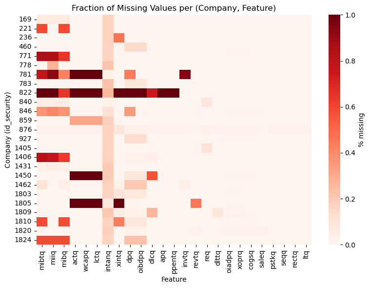

```python
max_companies = 25
max_features = 25

# Compute % of NaNs per (company, feature)
nan_rates = df.groupby('id_security')[feature_cols].apply(lambda g: g.isna().mean())
# nan_rates = df.groupby('id_security')[feature_cols + lag_feature_cols + macro_lag_cols].apply(lambda g: g.isna().mean())

# Filter top N companies with the most data
top_companies = df['id_security'].value_counts().head(max_companies).index
nan_rates = nan_rates.loc[nan_rates.index.isin(top_companies)]

# Optionally select most problematic features
if max_features is not None:
    feature_nans = nan_rates.mean(axis=0).sort_values(ascending=False).head(max_features).index
    nan_rates = nan_rates[feature_nans]

# Plot heatmap
fig = plt.figure(figsize=(8, 6))
sns.heatmap(nan_rates, cmap="Reds", cbar_kws={"label": "% missing"})
plt.xlabel("Feature")
plt.ylabel("Company (id_security)")

if save_plots:
    fig.savefig("plots/nan_heatmap.pdf", bbox_inches="tight")

plt.title("Fraction of Missing Values per (Company, Feature)")
plt.tight_layout()
plt.show()
```

## Time-based train/validation splits

We're going to evaluate model performance over different time periods ('time-series split'). A typical example would be:

- Fold 1: 2001-2005
- Fold 2: 2006-2010
- Fold 3: 2011-2015
- Fold 4: 2016-2020

Then, the cross-validation entails training on fold 1 and testing on 2, training on 1&2 and testing on 3, training on 1,2&3 and testing on 4.

The problem is that companies do not all "exist" in the same time periods. Let's examine this:

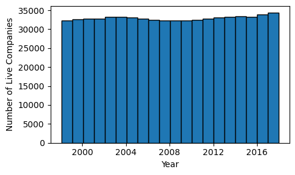

```python
# How many companies are "alive" during a given time period
fig,ax = plt.subplots(1, 1, figsize=(5, 3), sharey=False)
ax.hist(df['as_of_date'], bins=20, edgecolor='black')
ax.set_xlabel('Year')
ax.set_ylabel('Number of Live Companies')

plt.tight_layout()
plt.show()
```

We see that the number of "live" companies (or just the number of datapoints) is nearly uniform across time. Therefore, it makes sense to do something similar to the usual time series split, but instead of splitting into even time intervals, we'll split into intervals with the same number of points.

We'll also set aside data from 2016 onwards as the final holdout testing set. We will only use this set to evaluate the final model's "true" performance. This set is assigned fold number 99, it will not be part of cross-validation.

```python
def assign_folds(df, n_folds=5, test_start='2016-01-01'):
    df = df.copy()
    df = df.sort_values('as_of_date')

    df['fold'] = -1

    # Fold 99 for the testing set
    df.loc[df['as_of_date'] >= pd.Timestamp(test_start), 'fold'] = 99

    # Only use pre-test rows for CV folds
    train_idx = df[df['fold'] == -1].index
    fold_sizes = len(train_idx) // n_folds  # divide the data into folds of equal sizes

    edge_dates = [df.loc[train_idx[0], 'as_of_date']]

    start, end = 0, -1
    for k in range(n_folds):
        start = end + 1
        end += fold_sizes
        fold_idx = train_idx[start:end+1]
        df.loc[fold_idx, 'fold'] = k
        edge_dates.append(df.loc[train_idx[end], 'as_of_date'])

    edge_dates.append(pd.Timestamp(test_start))

    return df, edge_dates
```

```python
n_folds = 5
test_start = '2016-01-01'
df, edge_dates = assign_folds(df, n_folds=n_folds, test_start = test_start)
```

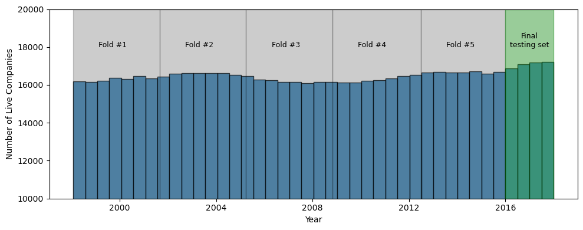

```python
# Plot for the folds

fig,ax = plt.subplots(1, 1, figsize=(10, 4), sharey=False)
ax.hist(df['as_of_date'], bins=40, edgecolor='black', alpha=0.7)
# ax.hist(df['datadate'], bins=20, edgecolor='black') # similar
ax.set_xlabel('Year')
ax.set_ylabel('Number of Live Companies')
ax.set_ylim(10000, 20000)

for i in range(n_folds):
    ax.axvspan(edge_dates[i], edge_dates[i+1], color='k', alpha=0.2)
    ax.text(edge_dates[i]+pd.Timedelta(600, "D"), 18000, f"Fold #{i+1}", ha='center', fontsize=9)

ax.axvspan(edge_dates[-1], pd.Timestamp('2018-01-01'), color='g', alpha=0.4)
ax.text(pd.Timestamp('2017-01-01'), 18000, "Final\ntesting set", ha='center', fontsize=9)

if save_plots:
    fig.savefig("plots/kfold_split.pdf", bbox_inches="tight")

plt.tight_layout()
plt.show()
```

## Build the training dataset

We now have all the features and are ready to build the final training dataset. To each row, we add the future quarters revenues (`revtq+1`,...,`revtq+4`). Those are the target variables.

```python
def build_training_rows_fast(df, feature_cols, n_horizon=4):

    df = df.sort_values(['id_security', 'as_of_date', 'datadate'])
    rows = []

    # Precompute: for each company, store the most recent revtq per future datadate  (chatgpt optimization!)
    future_targets = {}

    for cid, group in df.groupby('id_security'):
        # Build future map: datadate -> latest revtq (based on most recent as_of_date)
        future = (group[group['revtq'].notna()]
                  .sort_values(['datadate', 'as_of_date'])
                  .drop_duplicates('datadate', keep='last'))

        rev_map = dict(zip(future['datadate'], future['revtq']))
        future_targets[cid] = rev_map

    # Now iterate and build rows
    # tqdm for progress bar
    for cid, group in tqdm(df.groupby('id_security'), desc="Building training rows"):
        snapshots = group['as_of_date'].sort_values().unique()
        rev_map = future_targets[cid]

        for t in snapshots:
            snap_now = group[group['as_of_date'] == t]
            latest = snap_now[snap_now['datadate'] <= t]
            if latest.empty:
                continue
            latest = latest.sort_values('datadate').iloc[-1]
            X = latest[feature_cols]

            # Get 4 unique datadates after t from any row
            next_quarters = (group[group['datadate'] > t]
                             .sort_values('datadate')['datadate']
                             .drop_duplicates()
                             .head(n_horizon))

            if len(next_quarters) < n_horizon:
                continue

            y = [rev_map.get(d, np.nan) for d in next_quarters]  # returns nan if date missing instead of raising an error
            if any(pd.isna(y)):
                continue

            row = pd.Series(
                X.values.tolist() + y,
                index=feature_cols + [f'revtq+{k}' for k in range(1, n_horizon+1)]
            )

            # still need this metadata for indexing and analyzing
            row['as_of_date'] = t
            row['id_security'] = cid
            row['fold'] = latest.get('fold', -1)
            rows.append(row)

    return pd.DataFrame(rows)
```

```python
# This cell takes a long time
# What is taking time is finding the next 4 quarter revenues for each as_of_date. For every as_of_date, we parse every future as_of_date
# and record available datadates. We then select the next 4 distinct datadates and their revenues. That is what needs to be predicted.
# When two future as_of_date contain the same datadate, we select the most recent one, as it should be the "most" accurate information

# Full feature set
full_feature_cols = (
    feature_cols +
    lag_feature_cols +
    macro_lag_cols +
    categorical_linear_cols +       # one-hot encoded sector columns for Ridge
    categorical_non_linear_cols     # categorical columns for LightGBM
)

train_df = build_training_rows_fast(df, feature_cols=full_feature_cols, n_horizon=4)
# train_df.info()

target_cols = ['revtq+1', 'revtq+2', 'revtq+3', 'revtq+4'] # these now exist in train_df
```

## Training and evaluating the models

We are ready to test the models:

- Moving average (baseline)
- Ridge Regression (linear regression with L2 regularization). For this model, we scale every feature to zero mean and unit variance. We also need to remove all rows with NaN values.
- LightGBM (gradient boosted trees). This model natively handles NaN values.

We train and evaluate the models on the previously defined folds, and report the mean squared error (MSE) and mean absolute percentage error (MAPE) over the next 4 quarters. For MAPE, we use a modified version which limits the denominator to a small number >0.

We use sklearn's `MultiOutputRegressor` to ask the models (not MA) to regress for multiple targets (4 next quarters).

```python
def safe_mape(y_true, y_pred, eps=1e-5):
    y_true = np.asarray(y_true, dtype=float)
    y_pred = np.asarray(y_pred, dtype=float)

    denom = np.clip(np.abs(y_true), eps, None)  # avoid division by small or negative numbers
    return np.mean(np.abs((y_true - y_pred) / denom))
```

```python
def evaluate_models(train_df,
                    feature_cols_linear, feature_cols_lgb, categorical_cols_lgb,
                    ridge_alpha=1.0,
                    lgb_params=None):

    folds = [i for i in range(n_folds)]

    train_df = train_df[train_df['fold'] != -1] # exclude potential errors in folding (-1 was the default value of the fold)

    qmape_ma, qmape_ridge, qmape_lgb = [], [], [] # store the qmape errors for later plot

    for fold in folds[1:]:
        train = train_df[train_df['fold'] < fold]
        val = train_df[train_df['fold'] == fold]

        if train.empty or val.empty:
            print(f"Skipping fold {fold} due to empty train/val")
            continue

        print(f"Fold {fold}: train up to {train['as_of_date'].max().date()} | val = {val['as_of_date'].min().date()} -> {val['as_of_date'].max().date()}")

        ### --- Targets ---
        y_train = train[target_cols].values
        y_val = val[target_cols].values

        ### --- Baseline: Moving Average (per company) ---
        valid_ma_mask = val[['revtq_lag1', 'revtq_lag2']].notna().all(axis=1)
        ma_val = val.loc[valid_ma_mask, ['revtq_lag1', 'revtq_lag2']].mean(axis=1).values
        y_pred_ma = np.tile(ma_val.reshape(-1, 1), 4)
        y_val_ma = y_val[valid_ma_mask]

        ### --- Ridge Regression ---
        X_train_lr = train[feature_cols_linear].values
        X_val_lr = val[feature_cols_linear].values

        # Feature scaling (zero mean, unit variance)
        scaler = StandardScaler()
        X_train_lr = scaler.fit_transform(X_train_lr).astype(float)
        X_val_lr = scaler.transform(X_val_lr).astype(float)

        # Drop rows with NaNs from training set
        y_train = y_train.astype(float)
        y_val = y_val.astype(float)

        train_mask = ~np.isnan(X_train_lr).any(axis=1) & ~np.isnan(y_train).any(axis=1)
        X_train_lr_clean = X_train_lr[train_mask]
        y_train_clean = y_train[train_mask]

        val_mask = ~np.isnan(X_val_lr).any(axis=1) & ~np.isnan(y_val).any(axis=1)
        X_val_lr_clean = X_val_lr[val_mask]
        y_val_lr_clean = y_val[val_mask]

        if len(X_train_lr_clean) == 0 or len(y_train_clean) == 0:
            print(f"Skipping fold {fold} (Ridge) due to NaNs in training set")
            continue

        model_ridge = MultiOutputRegressor(Ridge(alpha=ridge_alpha))
        model_ridge.fit(X_train_lr_clean, y_train_clean)
        y_pred_ridge = model_ridge.predict(X_val_lr_clean)

        ### --- LightGBM ---
        X_train_lgb = train[feature_cols_lgb]
        X_val_lgb = val[feature_cols_lgb]

        model_lgb = MultiOutputRegressor(
            lgb.LGBMRegressor(**(lgb_params or {}))
        )
        model_lgb.fit(X_train_lgb, y_train, categorical_feature=categorical_cols_lgb)
        y_pred_lgb = model_lgb.predict(X_val_lgb)

        # --- Evaluate All ---
        for y_pred, y_val_val, name, store in zip(
            (y_pred_ma, y_pred_ridge, y_pred_lgb),
            (y_val_ma, y_val_lr_clean, y_val),
            ("Moving Avg", "Ridge", "LightGBM"),
            (qmape_ma, qmape_ridge, qmape_lgb)
        ):

            print(name)
            # overall errors
            mse = mean_squared_error(y_val_val, y_pred)
            # mape = mean_absolute_percentage_error(y_val_val, y_pred)
            mape = safe_mape(y_val_val, y_pred)

            # per quarter errors
            per_quarter_mse = [mean_squared_error(y_val_val[:, i], y_pred[:, i]) for i in range(4)]
            # per_quarter_mape = [mean_absolute_percentage_error(y_val_val[:, i], y_pred[:, i]) for i in range(4)]
            per_quarter_mape = [safe_mape(y_val_val[:, i], y_pred[:, i]) for i in range(4)]
            store.append(per_quarter_mape)

            # mse, mape, per_quarter_mse, per_quarter_mape = error_eval(y_val, y_pred)
            # store.append(per_quarter_mape)

            print(f"\t MSE  = {mse:.2f}  (quarters: {' | '.join(f'{x:.2f}' for x in per_quarter_mse)})")
            print(f"\t MAPE = {mape:.3f} (quarters: {' | '.join(f'{x:.3f}' for x in per_quarter_mape)})")

        print()

        # break

    return {
        'baseline': qmape_ma,
        'ridge': qmape_ridge,
        'lgb': qmape_lgb
    }
```

```python
# Define feature sets
linear_features = feature_cols + lag_feature_cols + macro_lag_cols + categorical_linear_cols
lgb_features = feature_cols + lag_feature_cols + macro_lag_cols + categorical_non_linear_cols
categorical_lgb = categorical_non_linear_cols

# lgb hyperparameter tuning
lgb_params={
    'n_estimators': 300,
    'learning_rate': 0.1,
    'max_depth': 6,
    'verbosity': -1
}

# Run the evaluation
results = evaluate_models(
    train_df,
    feature_cols_linear=linear_features,
    feature_cols_lgb=lgb_features,
    categorical_cols_lgb=categorical_lgb,
    ridge_alpha=1.0,
    lgb_params=lgb_params
)
```

```
Fold 1: train up to 2001-08-31 | val = 2001-08-31 -> 2005-03-31
Moving Avg
	 MSE  = 28136.53  (quarters: 16440.78 | 25546.41 | 32038.48 | 38520.44)
	 MAPE = 1308.584 (quarters: 662.456 | 1148.459 | 1466.858 | 1956.563)
Ridge
	 MSE  = 165985.35  (quarters: 146917.73 | 75390.22 | 39817.86 | 401815.58)
	 MAPE = 22993.431 (quarters: 4023.028 | 12226.701 | 8301.897 | 67422.099)
LightGBM
	 MSE  = 21788.21  (quarters: 16985.78 | 20708.14 | 28734.98 | 20723.94)
	 MAPE = 2393.870 (quarters: 866.391 | 2156.369 | 3009.078 | 3543.643)

Fold 2: train up to 2005-03-31 | val = 2005-03-31 -> 2008-10-31
Moving Avg
	 MSE  = 18570.29  (quarters: 13650.70 | 16227.56 | 20445.79 | 23957.13)
	 MAPE = 0.251 (quarters: 0.209 | 0.235 | 0.269 | 0.292)
Ridge
	 MSE  = 28339.09  (quarters: 13352.01 | 25167.69 | 34764.18 | 40072.48)
	 MAPE = 1.006 (quarters: 0.570 | 0.929 | 1.251 | 1.273)
LightGBM
	 MSE  = 37527.35  (quarters: 34516.93 | 34585.22 | 39274.37 | 41732.88)
	 MAPE = 0.284 (quarters: 0.268 | 0.281 | 0.279 | 0.307)

Fold 3: train up to 2008-10-31 | val = 2008-10-31 -> 2012-06-29
Moving Avg
	 MSE  = 13203.77  (quarters: 10495.69 | 11282.78 | 14451.92 | 16584.70)
	 MAPE = 0.207 (quarters: 0.176 | 0.189 | 0.220 | 0.243)
Ridge
	 MSE  = 17107.44  (quarters: 17723.63 | 20465.20 | 13774.35 | 16466.57)
	 MAPE = 0.587 (quarters: 0.700 | 0.669 | 0.518 | 0.460)
LightGBM
	 MSE  = 18574.04  (quarters: 13653.61 | 21463.40 | 18735.62 | 20443.52)
	 MAPE = 0.233 (quarters: 0.204 | 0.238 | 0.242 | 0.249)

Fold 4: train up to 2012-06-29 | val = 2012-06-29 -> 2015-12-31
Moving Avg
	 MSE  = 26412.99  (quarters: 19444.42 | 21935.93 | 28872.73 | 35398.88)
	 MAPE = 0.215 (quarters: 0.180 | 0.192 | 0.228 | 0.258)
Ridge
	 MSE  = 15231.74  (quarters: 11693.09 | 13155.19 | 15392.09 | 20686.60)
	 MAPE = 0.357 (quarters: 0.278 | 0.360 | 0.401 | 0.390)
LightGBM
	 MSE  = 41625.88  (quarters: 29990.21 | 38761.99 | 40455.55 | 57295.80)
	 MAPE = 0.198 (quarters: 0.175 | 0.189 | 0.198 | 0.232)
```

## Final performance evaluation on the test set

```python
target_cols = [f'revtq+{k}' for k in range(1, 5)]

# Train/val split
train_df = train_df[train_df['fold'] != -1]
train_data = train_df[train_df['fold'] < 5].copy()
test_data  = train_df[train_df['fold'] == 99].copy()

# Prepare inputs
X_train = train_data[lgb_features]
X_test  = test_data[lgb_features]
y_train = train_data[target_cols].values
y_test  = test_data[target_cols].values

# Fit model
model = MultiOutputRegressor(lgb.LGBMRegressor(**lgb_params))
model.fit(X_train, y_train, categorical_feature=categorical_lgb)
y_pred = model.predict(X_test)

# Errors
mse_total = mean_squared_error(y_test, y_pred)
mape_total = mean_absolute_percentage_error(y_test, y_pred)

qmse = [mean_squared_error(y_test[:, i], y_pred[:, i]) for i in range(4)]
qmape = [mean_absolute_percentage_error(y_test[:, i], y_pred[:, i]) for i in range(4)]

# Report
print("Final Evaluation on Test Set")
print(f"LightGBM MSE  = {mse_total:.2f} (quarters: " + ' | '.join(f"{x:.2f}" for x in qmse) + ")")
print(f"LightGBM MAPE = {mape_total:.3f} (quarters: " + ' | '.join(f"{x:.3f}" for x in qmape) + ")")
```

```
Final Evaluation on Test Set
LightGBM MSE  = 16437.99 (quarters: 16095.23 | 16688.62 | 16785.69 | 16182.42)
LightGBM MAPE = 0.211 (quarters: 0.227 | 0.211 | 0.198 | 0.208)
```

Let's group the errors by id_security and plot the distribution

```
id_security=448 : MAPE=0.04
id_security=570 : MAPE=0.04
id_security=581 : MAPE=0.05
id_security=694 : MAPE=0.04
id_security=768 : MAPE=0.04
id_security=876 : MAPE=0.04
id_security=879 : MAPE=0.04
id_security=897 : MAPE=0.04
id_security=1177 : MAPE=0.04
id_security=1273 : MAPE=-0.05
id_security=1498 : MAPE=0.05
id_security=1595 : MAPE=0.05
id_security=1648 : MAPE=0.04
id_security=1672 : MAPE=0.05
id_security=1682 : MAPE=0.04
```

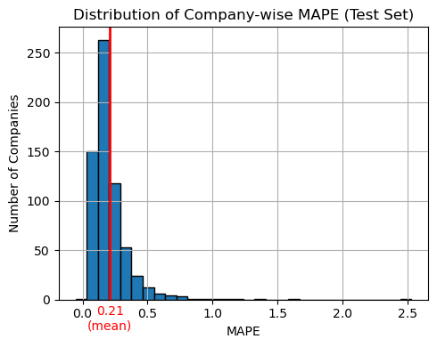

```python
# Create test set with actual and predicted values
test_df = test_data[['id_security'] + target_cols].copy()

# Add predictions from the last run
for i in range(4):
    test_df[f'y_pred_{i+1}'] = y_pred[:, i]

# Compute MAPE per company
company_mapes = []

for company_id, group in test_df.groupby('id_security'):
    y_true = group[[f'revtq+{i}' for i in range(1, 5)]].values
    y_predicted = group[[f'y_pred_{i}' for i in range(1, 5)]].values

    # Flatten arrays (1 row per company)
    y_true_flat = y_true.flatten()
    y_pred_flat = y_predicted.flatten()

    # Avoid div-by-zero; clip true values
    # mape = np.mean(np.abs(y_true_flat - y_pred_flat) / np.clip(y_true_flat, 1, None))
    if len(y_true_flat)==0 or len(y_pred_flat)==0:
        continue
    mape = np.mean(np.abs(y_true_flat - y_pred_flat) / y_true_flat)
    company_mapes.append(mape)

    # mark small errors as well predicted companies
    if mape < 0.05:
        print(f"id_security={company_id} : MAPE={mape:.2f}")

# Plot histogram
fig = plt.figure(figsize=(5, 4))
plt.hist(company_mapes, bins=30, edgecolor='black')
plt.xlabel("MAPE")
plt.ylabel("Number of Companies")
plt.grid(True)

# plot the overall mape from before
assert np.isclose(mape_total, np.mean(company_mapes), rtol=1e-2) # sanity check that the overall mape in both calculations are within 1%
plt.axvline(x=mape_total, ymin=-1, color='r', lw=2)
plt.text(mape_total, -30, f"{mape_total:.2f}\n(mean)", ha='center', color='r')

if save_plots:
    fig.savefig("plots/company_mape.pdf", bbox_inches="tight")

plt.title("Distribution of Company-wise MAPE (Test Set)")
plt.tight_layout()
plt.show()
```

## Make new predictions

Finally, you can use the function below to input a date, a security id (must be in the original dataset), and obtain a revenue forecast over the next 4 quarters. The model gets retrained on every function call, so this can take some time.

```python
def forecast_for_company_at_date(id_security, as_of_date):

    as_of_date = pd.to_datetime(as_of_date)

    # Split into training and prediction set
    train_subset = train_df[train_df['as_of_date'] < as_of_date].copy()
    as_of_date = train_subset['as_of_date'].max() # get an as_of_date in the dataset
    test_snapshot = train_df[(train_df['id_security'] == id_security) & (train_df['as_of_date'] == as_of_date)].copy()

    if test_snapshot.empty:
        print(f"No data available for company {id_security} at {as_of_date.date()}")
        return None, None

    # Prepare inputs
    X_train = train_subset[lgb_features].copy()
    y_train = train_subset[target_cols].values

    # Fit LightGBM model
    model = MultiOutputRegressor(lgb.LGBMRegressor(**lgb_params))
    model.fit(X_train, y_train, categorical_feature=categorical_lgb)

    X_test = test_snapshot[lgb_features].copy()
    y_pred = model.predict(X_test)[0]

    # Actual values
    y_true = test_snapshot[target_cols].values[0]

    # if len(future_quarters) < 4:
    #     future_quarters = np.append(future_quarters, [np.nan] * (4 - len(future_quarters)))

    # 6. Display
    print(f"\nForecast for Company {id_security} at {as_of_date.date()}:")
    for i in range(4):
        print(f"  Quarter +{i+1}: Predicted = {y_pred[i]:.2f}, Actual = {y_true[i]:.2f}")
    print()

    return y_pred, y_true
```

```python
# Some examples
_ = forecast_for_company_at_date(2, '2015-01-01')
_ = forecast_for_company_at_date(95, '2013-06-25')  # model is very accurate for id 95!
```

```
Forecast for Company 2 at 2014-12-31:
  Quarter +1: Predicted = 158.88, Actual = 138.76
  Quarter +2: Predicted = 168.61, Actual = 188.66
  Quarter +3: Predicted = 206.85, Actual = 225.61
  Quarter +4: Predicted = 214.46, Actual = 172.87


Forecast for Company 95 at 2013-05-31:
  Quarter +1: Predicted = 357.97, Actual = 354.05
  Quarter +2: Predicted = 360.65, Actual = 371.90
  Quarter +3: Predicted = 377.98, Actual = 410.56
  Quarter +4: Predicted = 388.36, Actual = 392.17
```